# Phasors

A series $RLC$ circuit is driven by an AC voltage source $V_s(t) = 325\,\sin\,(100\,\pi\,t)$. With $R = 10\,\Omega$ and $L = 100\,$mH, determine the value of the capacitance $C$ for which the voltage phasors across the capacitor and inductor are equal in magnitude. Find the angle between the two phasors.

(Follow the convention that $\cos\,(\omega \,t)$ corresponds to the phasor $1\,\angle {0}$.)

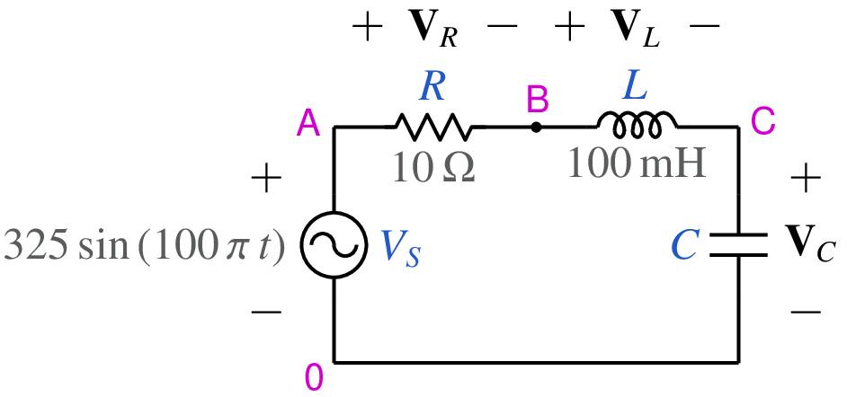

```python
from IPython.display import Image
Image(filename =r'phasor_1_fig_1.png', width=400)
```

```python
# run this cell to view the circuit file.
%pycat phasor_1_orig.in
```

We now replace the string \$C with the value of our choice by running the python script given below. It takes an existing circuit file `phasor_1_orig.in` and produces a new circuit file `phasor_1.in`, after replacing \$C with the value of our choice.

```python
import gseim_calc as calc
s_C = '200e-6' # to be changed by user
l = [
  ('$C', s_C),
]
calc.replace_strings_1("phasor_1_orig.in", "phasor_1.in", l)
print('phasor_1.in is ready for execution')
```

```
phasor_1.in is ready for execution
```

**Execute the following cell to run GSEIM on phasor_1.in.**

```python
import os
import dos_unix
# uncomment for windows:
#dos_unix.d2u("phasor_1.in")
os.system('run_gseim phasor_1.in')
```

```
Circuit: filename = phasor_1.in
GSEIM: Program completed.
```

```
0
```

The circuit file (`phasor_1.in`) is created in the same directory as that used for launching Jupyter notebook. The last step (i.e., running `GSEIM` on `phasor_1.in`) creates data files `phasor_1_1.dat` and `phasor_1_2.dat` in the same directory. We can now use the python code below to compute and display the quantities of interest.

```
filename: phasor_1_1.dat
phasors in rectangular form:
VR: (-148.05,  -95.51)
VL: ( 300.07, -465.12)
VC: (-152.02,  235.63)
Vs: (   0.00, -325.00)
IR: ( -14.81,   -9.55)
phasors in polar form:
VR: magnitude:  176.19, angle: -147.17 deg
VL: magnitude:  553.51, angle:  -57.17 deg
VC: magnitude:  280.41, angle:  122.83 deg
Vs: magnitude:  325.00, angle:  -90.00 deg
IR: magnitude:   17.62, angle: -147.17 deg
phi_L:  -57.2
phi_C:  122.8
phi_L-phi_C: -180.0
```

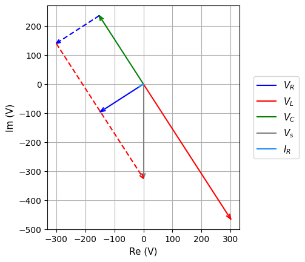

```python
import numpy as np
import gseim_calc as calc
import os
import sys
import dos_unix
import matplotlib.pyplot as plt
from matplotlib.ticker import (MultipleLocator, AutoMinorLocator)
from setsize import set_size

rad_to_deg = 180.0/np.pi

slv = calc.slv("phasor_1.in")

i_slv = 0
i_out = 0
filename = slv.l_filename_all[i_slv][i_out]
print('filename:', filename)
u = np.loadtxt(filename)
VR = slv.get_scalar_complex_1(i_slv, i_out, "VR_ac", u)
VC = slv.get_scalar_complex_1(i_slv, i_out, "VC_ac", u)
VL = slv.get_scalar_complex_1(i_slv, i_out, "VL_ac", u)
Vs = slv.get_scalar_complex_1(i_slv, i_out, "Vs_ac", u)
IR = slv.get_scalar_complex_1(i_slv, i_out, "IR_ac", u)

s_format = "%7.2f"

print('phasors in rectangular form:')

calc.print_complex_rect('VR', VR, s_format)
calc.print_complex_rect('VL', VL, s_format)
calc.print_complex_rect('VC', VC, s_format)
calc.print_complex_rect('Vs', Vs, s_format)
calc.print_complex_rect('IR', IR, s_format)

print('phasors in polar form:')

calc.print_complex_polar('VR', VR, s_format)
calc.print_complex_polar('VL', VL, s_format)
calc.print_complex_polar('VC', VC, s_format)
calc.print_complex_polar('Vs', Vs, s_format)
calc.print_complex_polar('IR', IR, s_format)

phi_L = np.angle(VL)*rad_to_deg
phi_C = np.angle(VC)*rad_to_deg

print('phi_L: %6.1f'%phi_L)
print('phi_C: %6.1f'%phi_C)
print('phi_L-phi_C: %6.1f'%(phi_L-phi_C))

l_colors = ["blue", "red", "green", "grey", "dodgerblue", "tomato"]

l1 = []
l1_labels = []

color_VR = calc.phasor_append_1a(l1, l1_labels, VR, "$V_R$", l_colors)
color_VL = calc.phasor_append_1a(l1, l1_labels, VL, "$V_L$", l_colors)
color_VC = calc.phasor_append_1a(l1, l1_labels, VC, "$V_C$", l_colors)
color_Vs = calc.phasor_append_1a(l1, l1_labels, Vs, "$V_s$", l_colors)
color_IR = calc.phasor_append_1a(l1, l1_labels, IR, "$I_R$", l_colors)

theta_deg = 20.0
length_arrow = calc.phasor_3(l1, 0.02)
l1_arrow = calc.phasor_2(l1, theta_deg, length_arrow, 0.2)

l2 = []
l2_colors = []

calc.phasor_append_2(l2, l2_colors, VC, (VR + VC), color_VR)
calc.phasor_append_2(l2, l2_colors, (VR + VC), (VR + VC + VL), color_VL)

l2_arrow = calc.phasor_2(l2, theta_deg, length_arrow, 0.2)

fig, ax = plt.subplots()
ax.set_aspect('equal', adjustable='box')
ax.grid()

for i, l_dummy in enumerate(l1_arrow):
    for k, t in enumerate(l_dummy):
        if (k == 0):
            ax.plot(t[0],t[1], color=l_colors[i], label=l1_labels[i])
        else:
            ax.plot(t[0],t[1], color=l_colors[i])

for i, l_dummy in enumerate(l2_arrow):
    for k, t in enumerate(l_dummy):
        ax.plot(t[0],t[1], color=l2_colors[i], linestyle='--', dashes=(4, 2))

calc.revise_axis_limits_1(ax, 3.0)
ax.legend(loc='center left', fontsize=11, bbox_to_anchor=(1.05, 0.5))

plt.xlabel('Re (V)', fontsize=11)
plt.ylabel('Im (V)', fontsize=11)
plt.show()
```

```
filename: phasor_1_2.dat
phasors in rectangular form:
SR: (1552.11,   -0.00)
SL: (   0.00, -2470.25)
SC: (   0.00, 4876.09)
SVs: (1552.11, 2405.83)
phasors in polar form:
SR: magnitude: 1552.11, angle:   -0.00 deg
SL: magnitude: 2470.25, angle:  -90.00 deg
SC: magnitude: 4876.09, angle:   90.00 deg
SVs: magnitude: 2863.05, angle:   57.17 deg
```

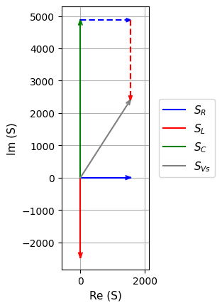

```python
import numpy as np
import gseim_calc as calc
import os
import sys
import dos_unix
import matplotlib.pyplot as plt
from matplotlib.ticker import (MultipleLocator, AutoMinorLocator)
from setsize import set_size

rad_to_deg = 180.0/np.pi

slv = calc.slv("phasor_1.in")

i_slv = 0
i_out = 1
filename = slv.l_filename_all[i_slv][i_out]
print('filename:', filename)
u = np.loadtxt(filename)
SR  = slv.get_scalar_complex_1(i_slv, i_out, "S_R",  u)
SC  = slv.get_scalar_complex_1(i_slv, i_out, "S_L",  u)
SL  = slv.get_scalar_complex_1(i_slv, i_out, "S_C",  u)
SVs = slv.get_scalar_complex_1(i_slv, i_out, "S_Vs", u)

s_format = "%7.2f"

print('phasors in rectangular form:')

calc.print_complex_rect('SR',  SR,  s_format)
calc.print_complex_rect('SL',  SL,  s_format)
calc.print_complex_rect('SC',  SC,  s_format)
calc.print_complex_rect('SVs', SVs, s_format)

print('phasors in polar form:')

calc.print_complex_polar('SR',  SR,  s_format)
calc.print_complex_polar('SL',  SL,  s_format)
calc.print_complex_polar('SC',  SC,  s_format)
calc.print_complex_polar('SVs', SVs, s_format)

l_colors = ["blue", "red", "green", "grey", "dodgerblue", "tomato"]

l1 = []
l1_labels = []

color_SR  = calc.phasor_append_1a(l1, l1_labels, SR,  "$S_R$",    l_colors)
color_SL  = calc.phasor_append_1a(l1, l1_labels, SL,  "$S_L$",    l_colors)
color_SC  = calc.phasor_append_1a(l1, l1_labels, SC,  "$S_C$",    l_colors)
color_SVs = calc.phasor_append_1a(l1, l1_labels, SVs, "$S_{Vs}$", l_colors)

theta_deg = 20.0
length_arrow = calc.phasor_3(l1, 0.02)
l1_arrow = calc.phasor_2(l1, theta_deg, length_arrow, 0.2)

l2 = []
l2_colors = []

calc.phasor_append_2(l2, l2_colors, SC, (SR + SC), color_SR)
calc.phasor_append_2(l2, l2_colors, (SR + SC), (SR + SC + SL), color_SL)

l2_arrow = calc.phasor_2(l2, theta_deg, length_arrow, 0.2)

fig, ax = plt.subplots()
ax.set_aspect('equal', adjustable='box')
ax.grid()

for i, l_dummy in enumerate(l1_arrow):
    for k, t in enumerate(l_dummy):
        if (k == 0):
            ax.plot(t[0],t[1], color=l_colors[i], label=l1_labels[i])
        else:
            ax.plot(t[0],t[1], color=l_colors[i])

for i, l_dummy in enumerate(l2_arrow):
    for k, t in enumerate(l_dummy):
        ax.plot(t[0],t[1], color=l2_colors[i], linestyle='--', dashes=(4, 2))

calc.revise_axis_limits_1(ax, 3.0)
ax.legend(loc='center left', fontsize=11, bbox_to_anchor=(1.05, 0.5))

plt.xlabel('Re (S)', fontsize=11)
plt.ylabel('Im (S)', fontsize=11)
plt.show()
```

This notebook was contributed by **Prof. Nakul Narayanan K**, Govt. Engineering College, Thrissur. He may be contacted at nakul@gectcr.ac.in.